# Introducing ordination: distance-based methods

Thomas Fuß

WS24/25

# Methods based on distance/dissimilarity/similarity

Pairs of samples/sites/objects can be more or less similar to each other based on multiple variables.

Two samples, which contain the same species with the same abundances (or exactly same environmental conditions), have the highest similarity (and lowest dissimilarity or distance); the similarity decreases (and dissimilarity/distance increases) with the differences in their species composition (or environmental conditions).

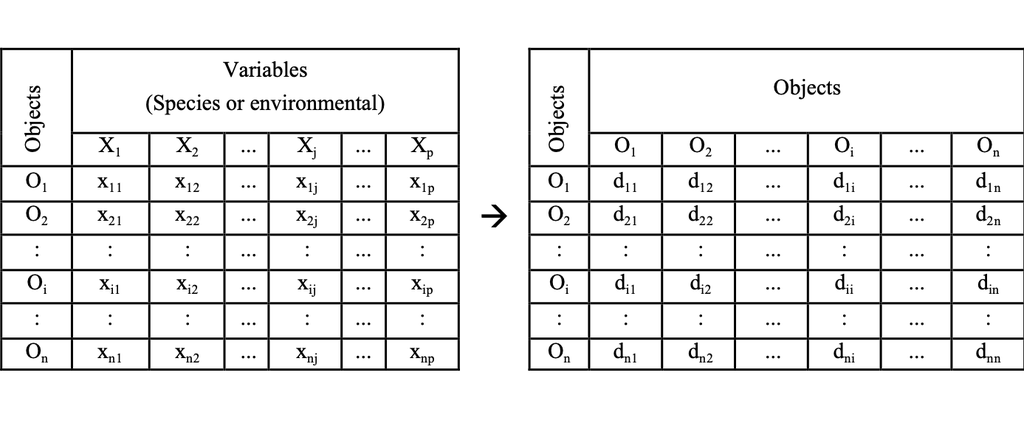

The most known dissimilarity is a (physical) distance: Euclidean distance, in a 2D-coordinate system it is just computed based on Pythagoras:

$$d_{Euc}=\sqrt{\Delta{x_1}^2+\Delta{x_2}^2}$$

Euclidean distance computed between any two sites for $p$ variables:

$$d_{Euc}=\sqrt{\Delta{x_1}^2+\Delta{x_2}^2+...+\Delta{x_p}^2}$$

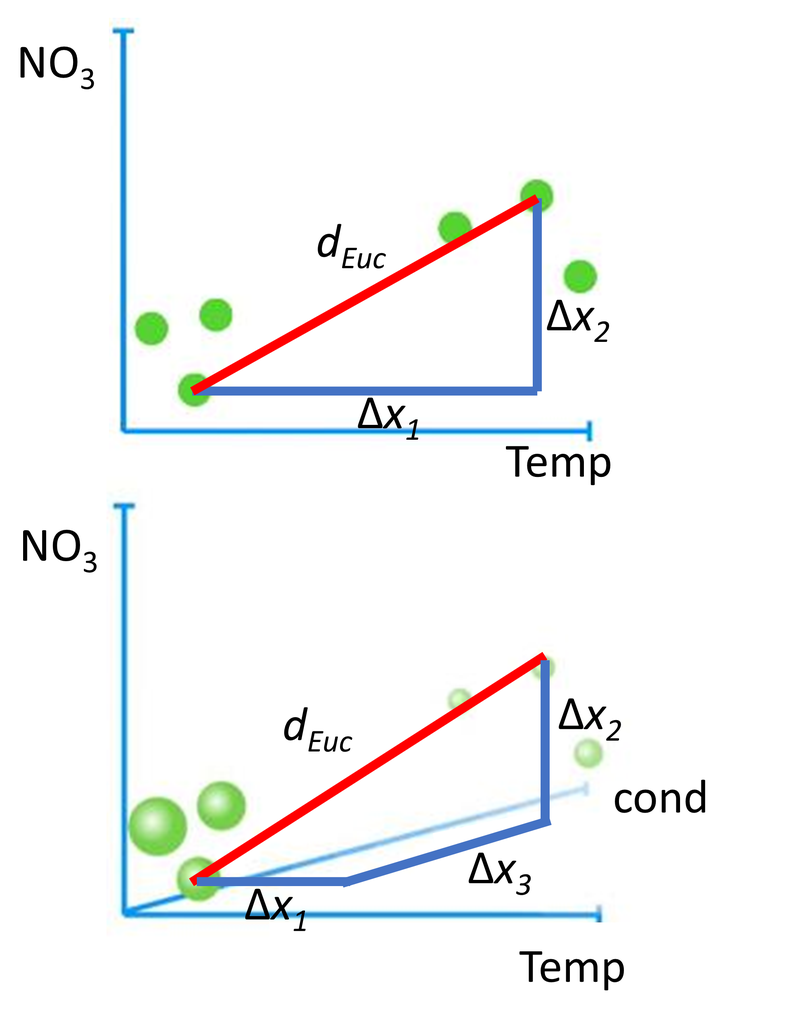

# Why use dissimilarity-based methods?

- Quantify how similar or how dissimilar various observations are with regard to many variables simultaneously.
- An efficient way to collapse information from a much too high-dimensional dataset.
- Use various variable types from continuous to presence-absence and qualitative, even simultaneously.
- Similarity may be translated into dissimilarity and vice-versa.
- Beta-diversity is based on dissimilarity measures, hence, they are an explicit way to express (and analyze) community turnover in space and time.

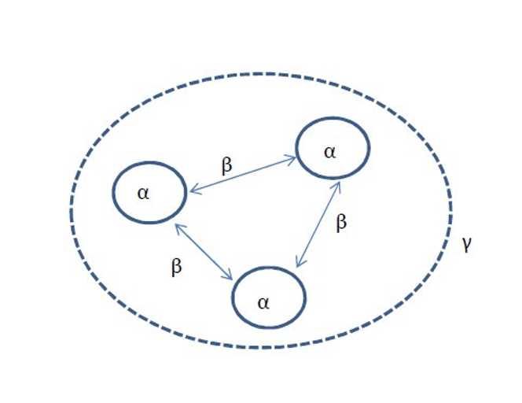

- Choice of appropriate dissimilarity coefficient may allow avoiding *strange* transformations.
- Better handling of double-zeros, less horseshoe patterns in ordinations in situations of strong community turnover.

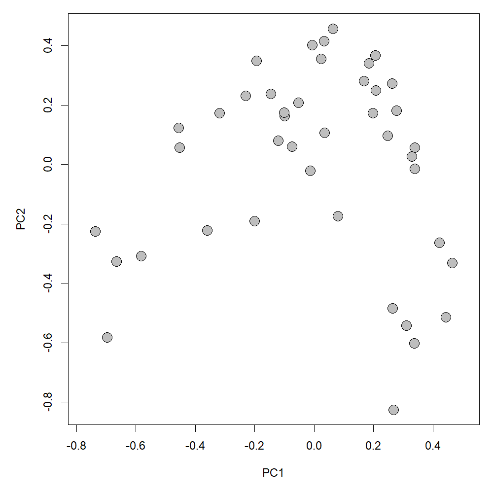

# (Dis)similarity coefficients

Two examples of dissimilarity indices here computed between any two sites for $p$ variables:

**Euclidean distance**

$$d_{Euc}=\sqrt{\Delta{x_1}^2+\Delta{x_2}^2+...+\Delta{x_p}^2}$$
where $\Delta{x}$ is the distance between two sites along any $X$-variable.

Binary version:
$$d_{Euc}=\sqrt{A+B-2J}$$
A and B are numbers of species at compared sites, and J is the number of species that occur on both compared sites.

**Bray-Curtis dissimilarity**
$$d_{BC}=\frac{\sum_{j=1}^p{|x_{1j}-x_{2j}|}}{\sum_{j=1}^p{(x_{1j}+x_{2j})}}$$
Binary version:
$$d_{BC}=\frac{A+B-2J}{A+B}$$

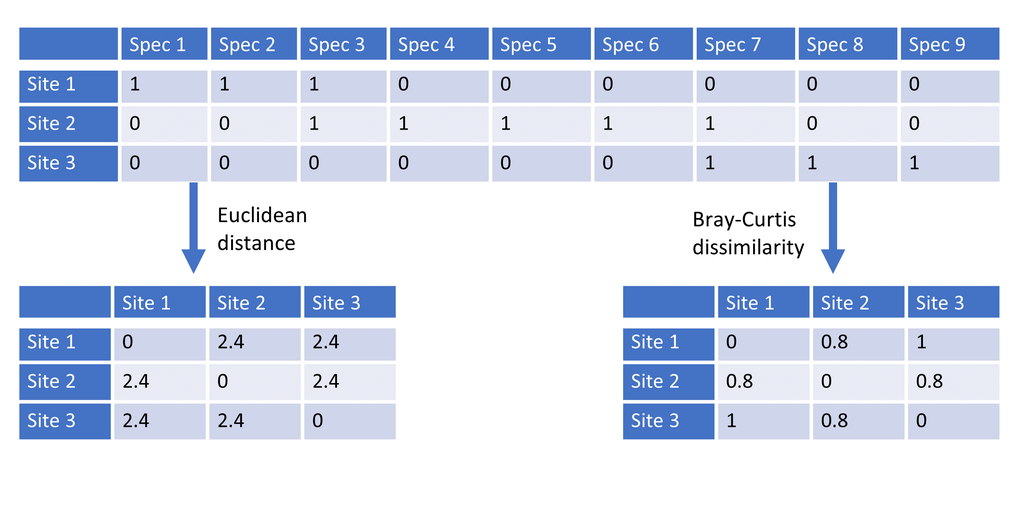

Double-zero (joint absences for two sites) problem: The fact that a species is missing does not say anything about ecological similarity or difference between both sites.

Double-zero can mean:

1. Sites are located outside of the species niche on the same side (sites A and B), which means sites are similar, or on opposite sites (A and C), which means sites are different.
2. Sites are located inside species niche (D and E), but the species does not occur because it didn’t get there (dispersal limitation), or it was present, but overlooked (sampling bias)

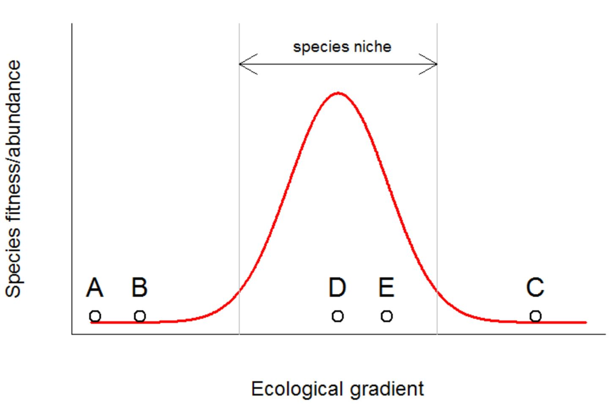

Bray-Curtis is well-suited for data on species composition because it ignores double-zeros.

Euclidean distance is useful for environmental data and especially for representing geographic space (from x/y coordinates), but rarely for species data.

# (Dis)similarity coefficients

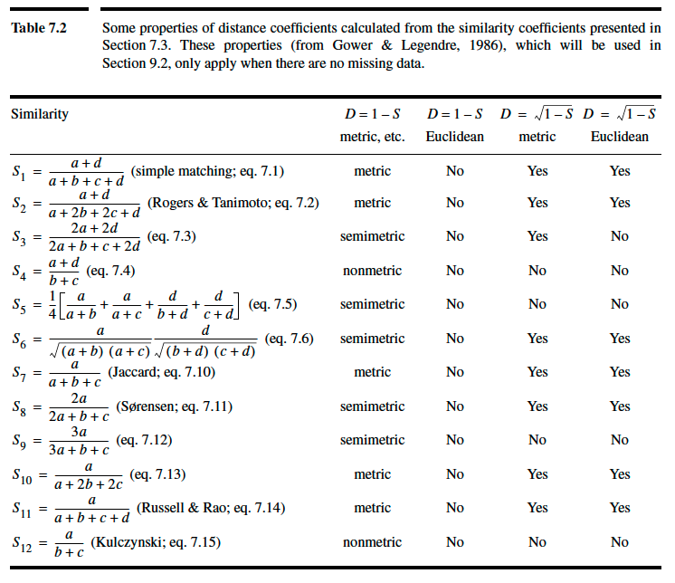

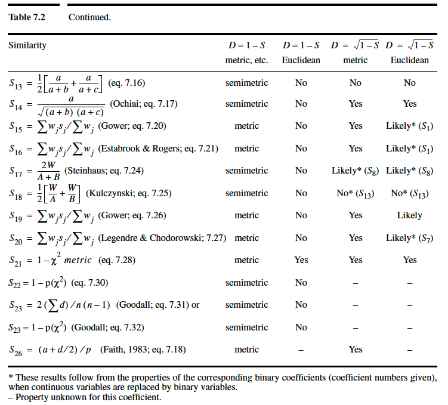

# (Dis)similarity coefficients: some properties

- symmetrical: consider a double zero as contributing to resemblance just like any other value
- asymmetrical: skip double zeros, considering that these are not informative (absence of a species at two sites does not tell anything about how similar these sites are!)
- metric: minimum 0, positive for inequality, symmetric ($D_{(a,b)}=D_{(b,a)}$), triangle inequality holds

$$D_{(a,b)}+D_{(b,c)}\geq{D_{(a,c)}}$$
* semimetric: do not follow the triangle inequality

$$D_{(a,b)}+D_{(b,c)}<{D_{(a,c)}}$$
… in which case perfect projections into Euclidean space are not possible. Two often used transformations to make semimetric coefficients analyzable in Euclidean space are adding a constant or $\sqrt(D)$.

Triangle inequality: Distance via an intermediate point must be higher than or equal to distance without such an intermediate point. E.g. consider B as intermediate between A and C as in a triangle: the distance from A to C via B must be larger than the direct distance from A to C.

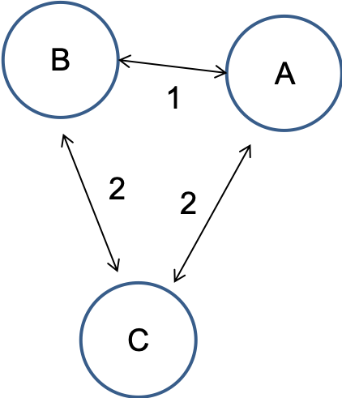

# Using dissimilarity: Non-metric multidimensional scaling (NMDS)

The goal: Collapse information from multiple dimensions into just a few, so they can be visualized and interpreted.

Iterative procedure:

1. Compute matrix of dissimilarities.
2. Decide on k, the number of reduced dimensions (typically 2).
3. Arrange objects (e.g. sites) in a random starting configuration.
4. Compute a measure of fit that expresses the match between inter-object distances of the configuration and the observed dissimilarities. A **Shepard-plot** shows residuals as stress which is inversely related to fit. The measure of fit is computed using **ranks of observed dissimilarities and configuration distances**. (smallest rank corresponding to smallest dissimilarity)
5. Reiteratively reposition the objects in the low-dimensional space and recompute fit to improve the match between inter-object distances and observed dissimilarities.
6. A final configuration is achieved when no more repositioning improves the fit (or reduces the stress). Steps 3) to 6) may be repeated with different random starting positions to avoid getting trapped in local minima.

# Non-metric multidimensional scaling (NMDS) in R

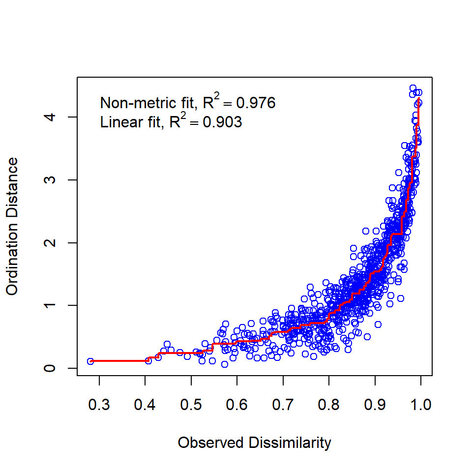

```r
# We sampled stream biofilm at 42 different streams across the Vjosa river network. Algal species were derived by 18S rRNA gene amplification
vjosa<-read.csv(file="data/data_vjosa.csv", sep=";") #load data
dim(vjosa) #
## [1]  42 662

com<-vjosa[,grep("ASV",names(vjosa))] # choose only ASV columns, these are the species
env<-vjosa[,-grep("ASV",names(vjosa))] # choose everything expect ASV


# We try to find the "best" reproduction of dissimilarities among sites in a 2 dimensional space.
# We use non-metric multidimensional scaling on Bray-Curtis dissimilarity matrix.

mds_vjosa <- metaMDS(comm = com, distance = "bray", k = 2) # to run a NMDS, $points to get scores, $stress to get information about fit
## Square root transformation
## Wisconsin double standardization
## Run 0 stress 0.1742853
## Run 1 stress 0.1853766
## Run 2 stress 0.1742853
## ... New best solution
## ... Procrustes: rmse 2.64764e-05  max resid 0.0001220507
## ... Similar to previous best
## Run 3 stress 0.1555025
## ... New best solution
## ... Procrustes: rmse 0.07805432  max resid 0.3845205
## Run 4 stress 0.1720438
## Run 5 stress 0.1572333
## Run 6 stress 0.1555025
## ... New best solution
## ... Procrustes: rmse 2.876438e-06  max resid 1.029209e-05
## ... Similar to previous best
## Run 7 stress 0.1555026
## ... Procrustes: rmse 0.0001253696  max resid 0.0004936047
## ... Similar to previous best
## Run 8 stress 0.1555025
## ... New best solution
## ... Procrustes: rmse 2.630782e-05  max resid 9.127394e-05
## ... Similar to previous best
## Run 9 stress 0.1624049
## Run 10 stress 0.1637225
## Run 11 stress 0.1555025
## ... Procrustes: rmse 5.632574e-05  max resid 0.000213458
## ... Similar to previous best
## Run 12 stress 0.1624049
## Run 13 stress 0.1833159
## Run 14 stress 0.1555026
## ... Procrustes: rmse 5.176445e-05  max resid 0.0002051233
## ... Similar to previous best
## Run 15 stress 0.1555025
## ... New best solution
## ... Procrustes: rmse 9.128518e-06  max resid 3.578814e-05
## ... Similar to previous best
## Run 16 stress 0.1555025
## ... Procrustes: rmse 2.029508e-05  max resid 6.963497e-05
## ... Similar to previous best
## Run 17 stress 0.1555025
## ... Procrustes: rmse 2.84255e-05  max resid 9.313011e-05
## ... Similar to previous best
## Run 18 stress 0.1979301
## Run 19 stress 0.1894487
## Run 20 stress 0.2024924
## *** Best solution repeated 3 times
mds_vjosa$stress
## [1] 0.1555025
## % of dissimilarities unrepresented
## Generally, stress < 0.05 provides an excellent represention in reduced
# dimensions, < 0.1 is great, < 0.2 is good, and stress > 0.3 provides a poor representation
# if high stress is a problem, the argument trymax (number of default iterations) or number of dimensions (e.g. k=3) can be increased

stressplot(mds_vjosa) # to compare configuration distances with observed dissimilarities
```

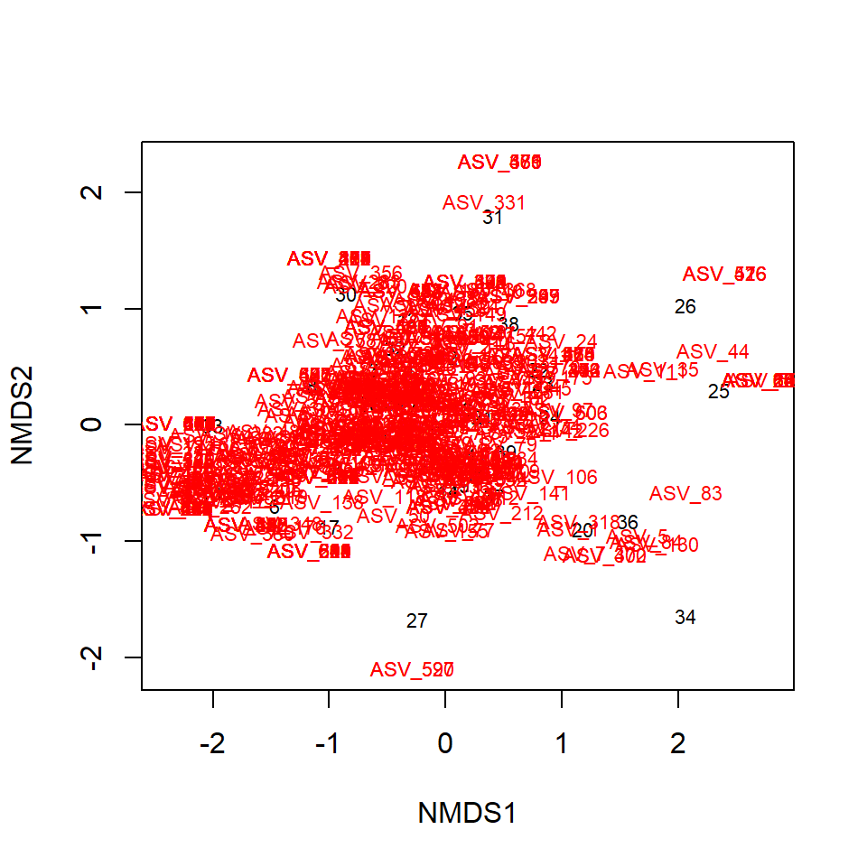

```r
goodness(mds_vjosa) # sample-specific goodness of fit
##  [1] 0.01797343 0.02117174 0.03075435 0.02266354 0.01875799 0.03030840
##  [7] 0.01756087 0.02204496 0.02533707 0.01858164 0.02069291 0.02263214
## [13] 0.02771618 0.02030960 0.01414603 0.01925585 0.03355964 0.01377055
## [19] 0.01551199 0.03023133 0.01754644 0.01956208 0.01845611 0.01855135
## [25] 0.03660484 0.02693934 0.03854815 0.02876442 0.02292746 0.04194374
## [31] 0.02756328 0.01684616 0.02297853 0.03021929 0.02105799 0.02601296
## [37] 0.01712468 0.02016921 0.01700964 0.01543156 0.01517806 0.02517505

#quick plot
plot(mds_vjosa, type="t")
```